# Diversity on College Campuses

# CMSC 320 Spring 2018 : Final Project

# Introduction

This project is a tutorial through the entire data science pipeline: data curation, parsing, and management; exploratory data analysis; hypothesis testing and machine learning to provide analysis; and the curation of a message or messages covering insights learned. We will explore datasets retrieved from US News containing different types of college statistics to see if there is a relationship between them. These characteristics are tuition, acceptance rate, enrollment, diversity, and presence of greek life. I believe diversity in schools is very important, so I would like to see if any of these factors contribute to it.

# Content

This tutorial will cover the following areas: 1. Data Curation and Parsing 2. Data Management 3. Exploratory Data Analysis 4. Hypothesis Testing and Machine Learning 5. Conclusion 6. Further Investigation and Additional Resources

# Data Curation and Parsing

First, let’s scrape the data from US News’ Best Colleges html table found in the site https://www.usnews.com/best-colleges/search?_mode=table&_sort=acceptance-rate&_sort-direction=asc, which lists the tuition, enrollment and acceptance rate of each college in the US. We must load the libraries that we will be using with library(). Then, we retrieve the table using html functions. Set the colunm names to their corresponding names with set_colnames().

In this table, the entities (rows) are each individual college, and the attributes (columns) are “Name/Rank”, “Tuition and Fees”, “Enrollment”, “Acceptance Rate”, and “Compare”. These are text, discrete numeric, discrete numeric, and discrete numeric respectively, while Compare is not a data type; it is merely an interactive tool on the website.

```r
library(rvest)
library(magrittr)
library(tibble)
url <- "https://www.usnews.com/best-colleges/search?_mode=table&_sort=acceptance-rate&_sort-direction=asc"
colleges <- url %>%
  read_html() %>%
  html_node("table") %>%
  html_table(fill=TRUE) %>%
  set_colnames(c("Name_Rank", "Tuition_and_Fees", "Enrollment", "Acceptance_Rate", "Compare")) %>%
  as_data_frame
colleges
```

```
## # A tibble: 23 x 5
##    Name_Rank           Tuition_and_Fees Enrollment Acceptance_Rate Compare
##    <chr>               <chr>            <chr>      <chr>           <lgl>
##  1 "Alice Lloyd Colle~ $12,050          599        4%              NA
##  2 "Curtis Institute ~ $2,525           N/A        4%              NA
##  3 "Harvard Universit~ $48,949          6,710      5%              NA
##  4 "Stanford Universi~ $49,617          7,034      5%              NA
##  5 "Columbia Universi~ $57,208          6,113      6%              NA
##  6 ""                  <NA>             <NA>       <NA>            NA
##  7 "Yale University\n~ $51,400          5,472      6%              NA
##  8 "Juilliard School\~ $41,410          580        7%              NA
##  9 "Princeton Univers~ $47,140          5,400      7%              NA
## 10 "California Instit~ $49,908          979        8%              NA
## # ... with 13 more rows
```

As you may have noticed, the table retrieved from the site’s URL only includes 23 rows. This is because more rows load on the website as one scrolls down. However, the URL does not seem to change when scrolling. When hovering the cursor over the “Load More” option, I found that the URL that appears on the bottom left corner of the browser includes “&_page=" at the end. Through a quick trial and error of editing the URL with different page numbers, I found that the last page is 90.

In order to combine the tables from all these pages, iterate through all of them with a for-loop, and combine them with function rbind().

At the end, we use the slice() function in order to only print out a partial output for demonstration, and not all 90 pages.

```r
library(dplyr)
for(i in 2:90){
  page_url <- paste(url, i, sep="&_page=")

colleges_page <- page_url %>%
  read_html() %>%
  html_node("table") %>%
  html_table(fill=TRUE) %>%
  set_colnames(c("Name_Rank", "Tuition_and_Fees", "Enrollment", "Acceptance_Rate", "Compare")) %>%
  as_data_frame

colleges <- rbind(colleges, colleges_page)
}
colleges %>% slice(1:20)
```

```
## # A tibble: 20 x 5
##    Name_Rank          Tuition_and_Fees  Enrollment Acceptance_Rate Compare
##    <chr>              <chr>             <chr>      <chr>           <lgl>
##  1 "Alice Lloyd Coll~ $12,050           599        4%              NA
##  2 "Curtis Institute~ $2,525            N/A        4%              NA
##  3 "Harvard Universi~ $48,949           6,710      5%              NA
##  4 "Stanford Univers~ $49,617           7,034      5%              NA
##  5 "Columbia Univers~ $57,208           6,113      6%              NA
##  6 ""                 <NA>              <NA>       <NA>            NA
##  7 "Yale University\~ $51,400           5,472      6%              NA
##  8 "Juilliard School~ $41,410           580        7%              NA
##  9 "Princeton Univer~ $47,140           5,400      7%              NA
## 10 "California Insti~ $49,908           979        8%              NA
## 11 "Jarvis Christian~ $11,720           900        8%              NA
## 12 ""                 <NA>              <NA>       <NA>            NA
## 13 "Massachusetts In~ $49,892           4,524      8%              NA
## 14 "United States Na~ N/A (out-of-stat~ 4,526      8%              NA
## 15 "University of Ch~ $54,825           5,941      8%              NA
## 16 "Brown University~ $53,419           6,926      9%              NA
## 17 "Claremont McKenn~ $52,825           1,347      9%              NA
## 18 ""                 <NA>              <NA>       <NA>            NA
## 19 "Pomona College\n~ $51,075           1,660      9%              NA
## 20 "University of Pe~ $53,534           10,019     9%              NA
```

```r
library(readr)
library(stringr)
colleges <- colleges %>%
  select(1:4) %>%
  mutate(Tuition_and_Fees = str_replace_all(Tuition_and_Fees, ",", "")) %>%
  mutate(Tuition_and_Fees = str_replace_all(Tuition_and_Fees, "\\$", "")) %>%
  mutate(Enrollment = str_replace_all(Enrollment, ",", "")) %>%
  mutate(Acceptance_Rate = str_replace_all(Acceptance_Rate, "%", "")) %>%
  type_convert(cols("Tuition_and_Fees"= col_integer(), "Enrollment"= col_integer(), "Acceptance_Rate" = col_integer())) %>%
  mutate(Acceptance_Rate = Acceptance_Rate/100) %>%
  mutate(Name_Rank = str_replace_all(Name_Rank, "\n[ ]*.*", "")) %>%
  rename(Name = Name_Rank)

colleges %>% slice(1:20)
```

```
## # A tibble: 20 x 4
##    Name                        Tuition_and_Fees Enrollment Acceptance_Rate
##    <chr>                                  <int>      <int>           <dbl>
##  1 Alice Lloyd College                    12050        599          0.0400
##  2 Curtis Institute of Music               2525         NA          0.0400
##  3 Harvard University                     48949       6710          0.0500
##  4 Stanford University                    49617       7034          0.0500
##  5 Columbia University                    57208       6113          0.0600
##  6 <NA>                                      NA         NA         NA
##  7 Yale University                        51400       5472          0.0600
##  8 Juilliard School                       41410        580          0.0700
##  9 Princeton University                   47140       5400          0.0700
## 10 California Institute of Te~            49908        979          0.0800
## 11 Jarvis Christian College               11720        900          0.0800
## 12 <NA>                                      NA         NA         NA
## 13 Massachusetts Institute of~            49892       4524          0.0800
## 14 United States Naval Academy               NA       4526          0.0800
## 15 University of Chicago                  54825       5941          0.0800
## 16 Brown University                       53419       6926          0.0900
## 17 Claremont McKenna College              52825       1347          0.0900
## 18 <NA>                                      NA         NA         NA
## 19 Pomona College                         51075       1660          0.0900
## 20 University of Pennsylvania             53534      10019          0.0900
```

Now, repeat the above steps for the dataset with college names and the percentage of greek life from https://www.usnews.com/best-colleges/rankings/most-frats.

```r
url <- "https://www.usnews.com/best-colleges/rankings/most-frats"
greek <- url %>%
  read_html() %>%
  html_node("table") %>%
  html_table(fill=TRUE) %>%
  set_colnames(c("School", "Greek_Life")) %>%
  as_data_frame

for(i in 2:10){
  page_url <- paste(url, i, sep="?_page=")

greek_page <- page_url %>%
  read_html() %>%
  html_node("table") %>%
  html_table(fill=TRUE) %>%
  set_colnames(c("School", "Greek_Life")) %>%
  as_data_frame

greek <- rbind(greek, greek_page)
}

greek <- greek %>%
  mutate(Greek_Life = str_replace_all(Greek_Life, "%", "")) %>%
  type_convert(cols("Greek_Life"= col_integer())) %>%
  mutate(Greek_Life = Greek_Life/100) %>%
  mutate(School = str_replace_all(School, "\n[ ]*.*", ""))

greek %>% slice(1:20)
```

```
## # A tibble: 20 x 2
##    School                                Greek_Life
##    <chr>                                      <dbl>
##  1 DePauw University                          0.750
##  2 Washington and Lee University              0.730
##  3 Sewanee--University of the South           0.700
##  4 Wabash College                             0.650
##  5 Millsaps College                           0.610
##  6 Welch College                              0.520
##  7 Transylvania University                    0.500
##  8 Wofford College                            0.500
##  9 Massachusetts Institute of Technology      0.460
## 10 Stevens Institute of Technology            0.460
## 11 Ohio Valley University                     0.450
## 12 Dartmouth College                          0.430
## 13 William Woods University                   0.430
## 14 Hanover College                            0.420
## 15 Ripon College                              0.410
## 16 Texas Christian University                 0.410
## 17 Centre College                             0.400
## 18 Lehigh University                          0.400
## 19 William Jewell College                     0.400
## 20 Bucknell University                        0.390
```

```r
url <- "https://www.usnews.com/best-colleges/rankings/national-universities/campus-ethnic-diversity"
diversity <- url %>%
  read_html() %>%
  html_node("table") %>%
  html_table(fill=TRUE) %>%
  set_colnames(c("School", "Diversity_Index")) %>%
  as_data_frame

for(i in 2:30){
  page_url <- paste(url, i, sep="?_page=")

diversity_page <- page_url %>%
  read_html() %>%
  html_node("table") %>%
  html_table(fill=TRUE) %>%
  set_colnames(c("School", "Diversity_Index")) %>%
  as_data_frame

diversity <- rbind(diversity, diversity_page)
}
diversity <- diversity %>%
    mutate(School = str_replace_all(School, "(-+).*|(\n[ ]*).*", ""))
diversity %>% slice(1:20)
```

```
## # A tibble: 20 x 2
##    School                                Diversity_Index
##    <chr>                                           <dbl>
##  1 Andrews University                              0.750
##  2 Rutgers University                              0.750
##  3 University of Nevada                            0.750
##  4 Stanford University                             0.740
##  5 University of Houston                           0.740
##  6 San Francisco State University                  0.730
##  7 University of Hawaii                            0.730
##  8 University of San Francisco                     0.730
##  9 University of California                        0.720
## 10 University of Illinois                          0.720
## 11 Georgia State University                        0.710
## 12 Massachusetts Institute of Technology           0.710
## 13 New Jersey Institute of Technology              0.710
## 14 Nova Southeastern University                    0.710
## 15 Texas Woman's University                        0.710
## 16 University of California                        0.710
## 17 University of California                        0.710
## 18 University of California                        0.710
## 19 University of Texas                             0.710
## 20 University of Texas                             0.710
```

# Data Management

```r
colleges_and_greek <- inner_join(colleges, greek, by= c("Name" = "School"))
colleges_and_greek %>% slice(1:20)
```

```
## # A tibble: 20 x 5
##    Name             Tuition_and_Fees Enrollment Acceptance_Rate Greek_Life
##    <chr>                       <int>      <int>           <dbl>      <dbl>
##  1 Massachusetts I~            49892       4524          0.0800      0.460
##  2 University of P~            53534      10019          0.0900      0.300
##  3 Dartmouth Colle~            52950       4310          0.110       0.430
##  4 Northwestern Un~            52678       8353          0.110       0.290
##  5 Vanderbilt Univ~            47664       6871          0.110       0.370
##  6 Cornell Univers~            52853      14566          0.140       0.250
##  7 University of S~            54259      18794          0.170       0.260
##  8 Washington Univ~            51533       7540          0.170       0.300
##  9 Davidson College            49949       1796          0.200       0.390
## 10 Washington and ~            50170       1830          0.240       0.730
## 11 Emory University            49392       6861          0.250       0.270
## 12 American Univer~            46615       7901          0.260       0.240
## 13 Hamilton College            52770       1879          0.260       0.260
## 14 Lehigh Universi~            50740       5080          0.260       0.400
## 15 Tulane Universi~            52960       6377          0.260       0.300
## 16 Bucknell Univer~            53986       3571          0.300       0.390
## 17 Wake Forest Uni~            51400       4955          0.300       0.350
## 18 Case Western Re~            47500       5152          0.350       0.310
## 19 College of Will~               NA       6276          0.370       0.260
## 20 Pepperdine Univ~            51992       3542          0.370       0.240
```

```r
colleges_and_diversity <- inner_join(colleges, diversity, by= c("Name" = "School"))
colleges_and_diversity %>% slice(1:20)
```

```
## # A tibble: 20 x 5
##    Name        Tuition_and_Fees Enrollment Acceptance_Rate Diversity_Index
##    <chr>                  <int>      <int>           <dbl>           <dbl>
##  1 Harvard Un~            48949       6710          0.0500           0.680
##  2 Stanford U~            49617       7034          0.0500           0.740
##  3 Columbia U~            57208       6113          0.0600           0.700
##  4 Yale Unive~            51400       5472          0.0600           0.660
##  5 Princeton ~            47140       5400          0.0700           0.660
##  6 California~            49908        979          0.0800           0.660
##  7 Massachuse~            49892       4524          0.0800           0.710
##  8 University~            54825       5941          0.0800           0.630
##  9 Brown Univ~            53419       6926          0.0900           0.630
## 10 University~            53534      10019          0.0900           0.650
## 11 Dartmouth ~            52950       4310          0.110            0.630
## 12 Duke Unive~            53744       6609          0.110            0.640
## 13 Northweste~            52678       8353          0.110            0.630
## 14 Vanderbilt~            47664       6871          0.110            0.590
## 15 Johns Hopk~            52170       6117          0.120            0.690
## 16 Cornell Un~            52853      14566          0.140            0.650
## 17 Tufts Univ~            54318       5508          0.140            0.500
## 18 Rice Unive~            45608       3893          0.150            0.690
## 19 Georgetown~            52300       7453          0.170            0.530
## 20 University~            54259      18794          0.170            0.680
```

```r
diversity_and_greek <- inner_join(diversity, greek, by = "School")
diversity_and_greek %>% slice(1:20)
```

```
## # A tibble: 20 x 3
##    School                                Diversity_Index Greek_Life
##    <chr>                                           <dbl>      <dbl>
##  1 Massachusetts Institute of Technology           0.710      0.460
##  2 University of Southern California               0.680      0.260
##  3 Cornell University                              0.650      0.250
##  4 Emory University                                0.650      0.270
##  5 University of Pennsylvania                      0.650      0.300
##  6 Montclair State University                      0.640      0.350
##  7 Dartmouth College                               0.630      0.430
##  8 Northwestern University                         0.630      0.290
##  9 Pepperdine University                           0.590      0.240
## 10 Vanderbilt University                           0.590      0.370
## 11 Case Western Reserve University                 0.580      0.310
## 12 University of San Diego                         0.580      0.240
## 13 Washington University in St. Louis              0.580      0.300
## 14 University of Alabama                           0.560      0.270
## 15 Rensselaer Polytechnic Institute                0.530      0.300
## 16 University of Oklahoma                          0.530      0.240
## 17 American University                             0.520      0.240
## 18 Syracuse University                             0.520      0.260
## 19 College of William and Mary                     0.500      0.260
## 20 Southern Methodist University                   0.470      0.280
```

# Exploratory Data Analysis

Now, let’s graph different functions using ggplot to see if there is a relationship between these college characteristics. Geom_point() maps the data as a scatter-plot, and geom_smooth() graphs a line of best fit.

Plot Tuition as a function of Acceptance Rate.

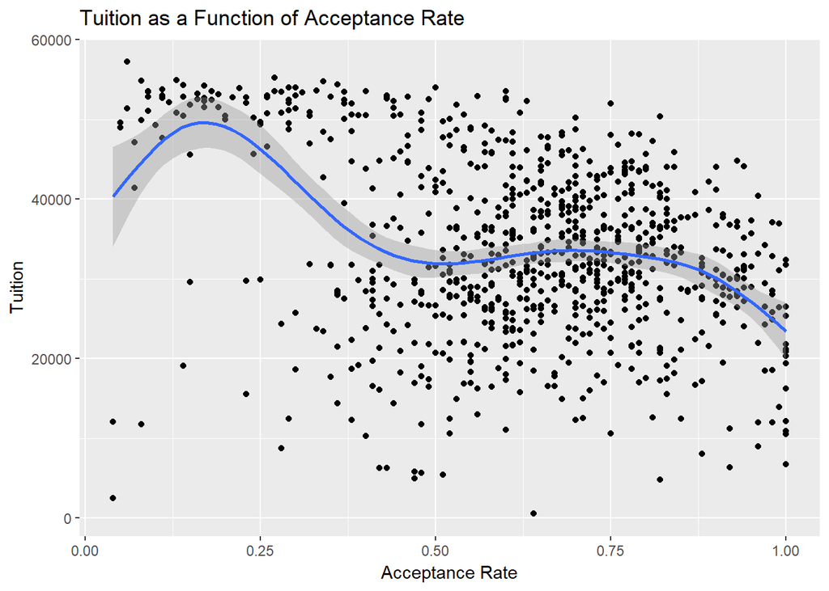

```r
library(ggplot2)
colleges %>%
  ggplot(aes(x=Acceptance_Rate, y=Tuition_and_Fees)) +
    geom_point() + geom_smooth() +
    labs(title="Tuition as a Function of Acceptance Rate", x = "Acceptance Rate", y = "Tuition")
```

There seems to be a slight relationship between these attributes.

Plot Enrollment as a function of Tuition.

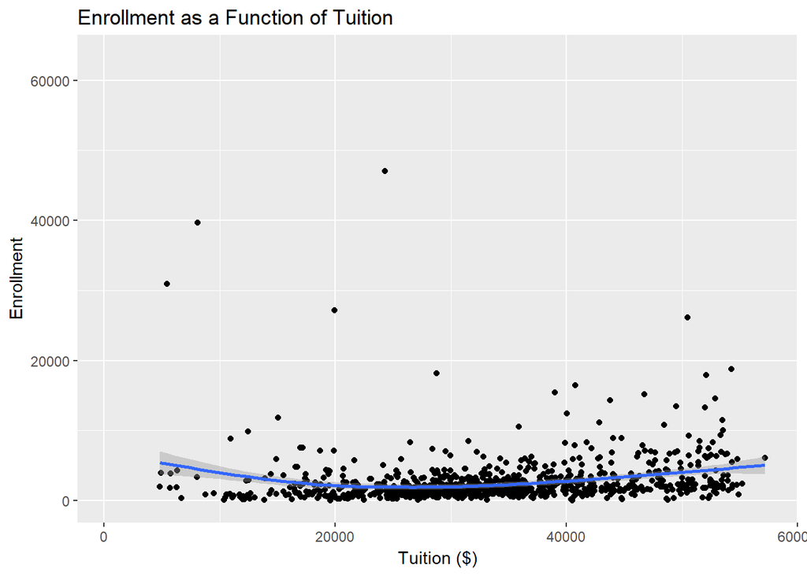

```r
colleges %>%
  ggplot(aes(x=Tuition_and_Fees, y=Enrollment)) +
    geom_point() + geom_smooth() +
    labs(title="Enrollment as a Function of Tuition", x = "Tuition ($)", y = "Enrollment")
```

The enrollment size does not seem to be correlated with tuition.

Plot Greek Life as a function of Tuition.

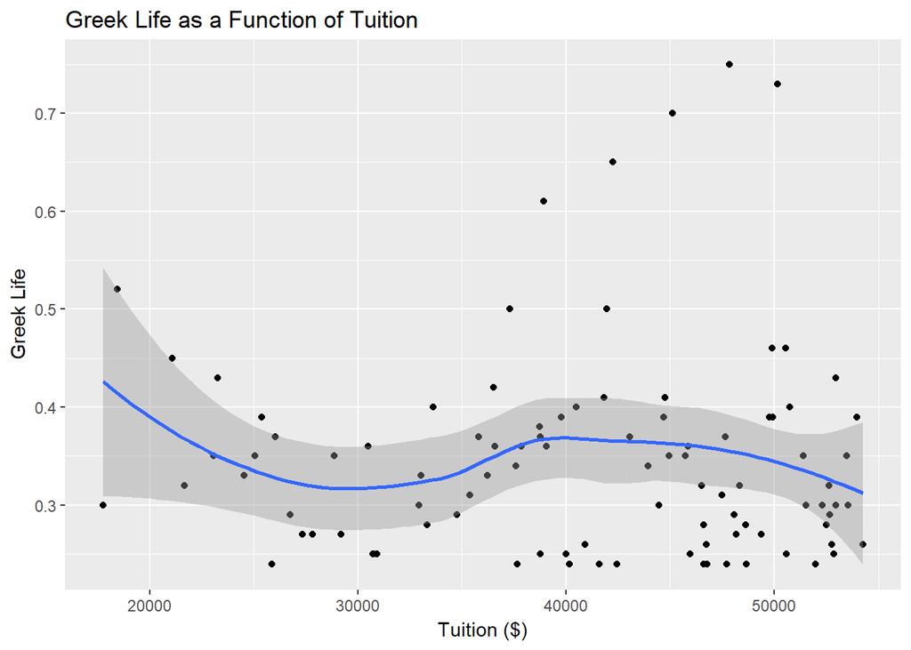

```r
colleges_and_greek %>%
  ggplot(aes(x=Tuition_and_Fees, y=Greek_Life)) +
    geom_point() + geom_smooth() +
    labs(title="Greek Life as a Function of Tuition", x = "Tuition ($)", y = "Greek Life")
```

There appears to be a slight relationship between greek life size and tuition.

Plot Greek Life as a function of Acceptance Rate.

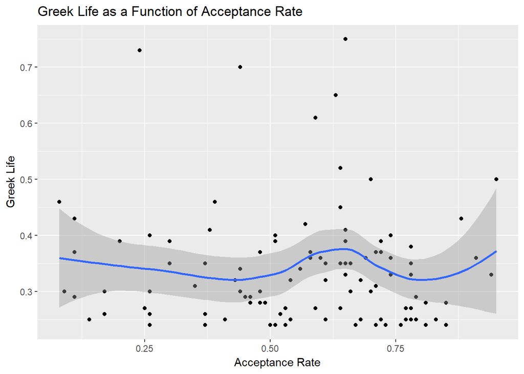

```r
colleges_and_greek %>%
  ggplot(aes(x=Acceptance_Rate, y=Greek_Life)) +
    geom_point() + geom_smooth() +
    labs(title="Greek Life as a Function of Acceptance Rate", x = "Acceptance Rate", y = "Greek Life")
```

It does not seem like acceptance rate affects the size of greek life in colleges.

Plot Diversity as a function of Acceptance Rate.

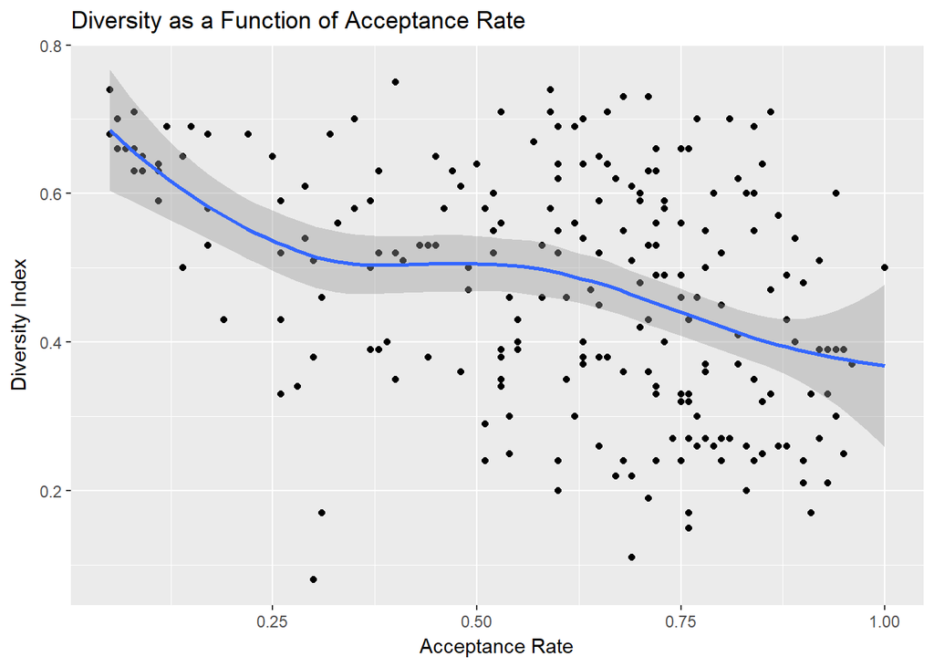

```r
colleges_and_diversity %>%
  ggplot(aes(x=Acceptance_Rate, y=Diversity_Index)) +
    geom_point() + geom_smooth() +
    labs(title="Diversity as a Function of Acceptance Rate", x = "Acceptance Rate", y = "Diversity Index")
```

There appears to be a relationship between how selective a school is and how diverse its student body.

Plot Diversity as a function of Tuition.

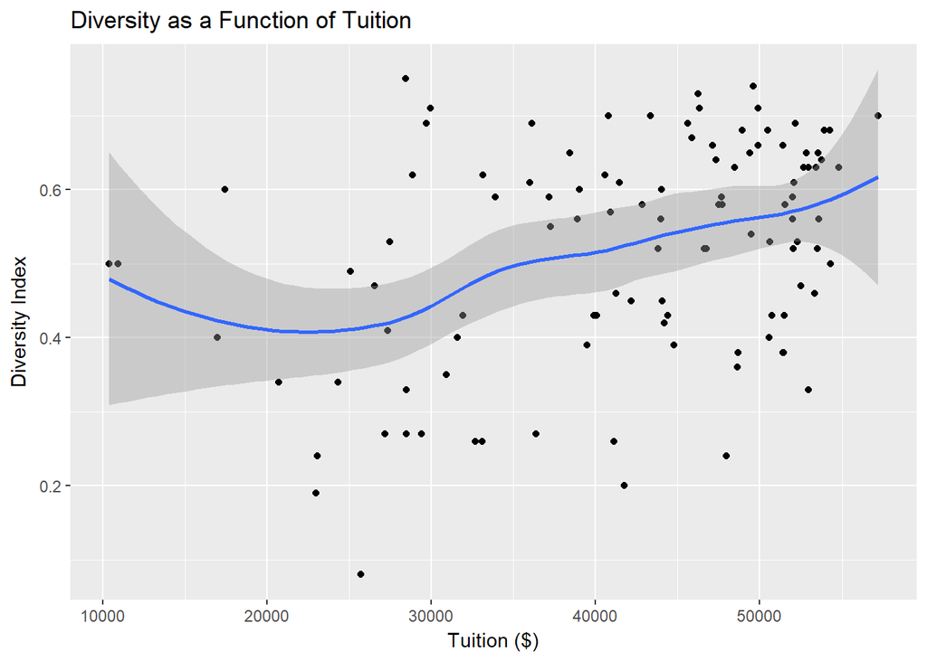

```r
colleges_and_diversity %>%
  ggplot(aes(x=Tuition_and_Fees, y=Diversity_Index)) +
    geom_point() + geom_smooth() +
    labs(title="Diversity as a Function of Tuition", x = "Tuition ($)", y = "Diversity Index")
```

Likewise, there appears to be a relationship between the cost of attending a school and its diversity index.

Plot Greek Life as a function of Diversity.

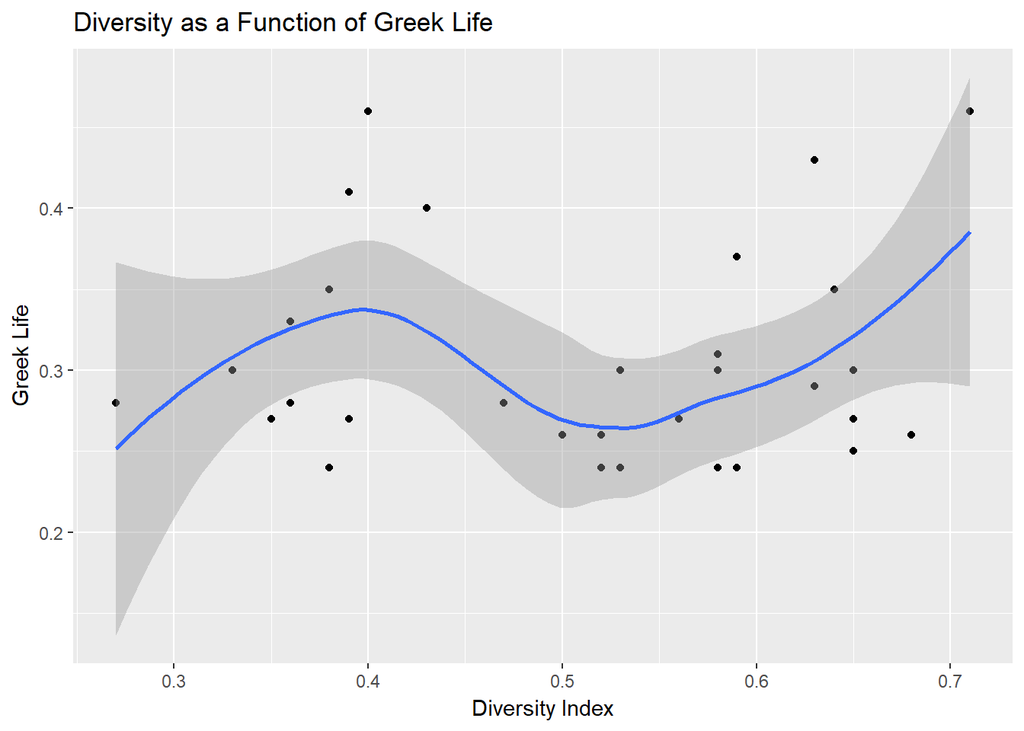

```r
diversity_and_greek %>%
  ggplot(aes(x=Diversity_Index, y=Greek_Life)) +
    geom_point() + geom_smooth() +
    labs(title="Diversity as a Function of Greek Life", x = "Diversity Index", y = "Greek Life")
```

There seems to be a slight relationship between a school’s diversity index and the size of its greek life on campus.